# Bank Churn Prediction

##### Model using Neural Network

```python
# function to create model based on parameter 'layers'
def create_model(layers):
    # neural network
    model = Sequential()

    for layer in layers:
        model.add(layer)

    # metric
    recall_metric = tf.keras.metrics.Recall()

    # compile the model
    model.compile(optimizer='adam',
                  loss='binary_crossentropy',
                  metrics=[recall_metric]
                 )
    return model
```

```python
# define the layers to be used by the mode
# first hidden layer with n units and second hidden layer with 2n+1
model_layers_13_27 = [
    Dense(13, activation='relu'),
    Dense(27, activation='relu'),
    Dense(1, activation=tf.keras.activations.sigmoid)
]

model = create_model(model_layers_13_27)
```

```python
%%time
# fit the model
history = model.fit(X_train, y_train, epochs=20,validation_split=0.2)
```

```
Wall time: 4.85 s
```

```
Accuracy=0.858 - Precision=0.705 - Recall=0.491 - F1 Score=0.579
```

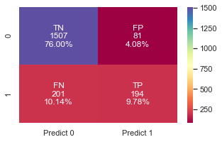

```
No Skill: ROC AUC=0.500
Model: ROC AUC=0.882
```

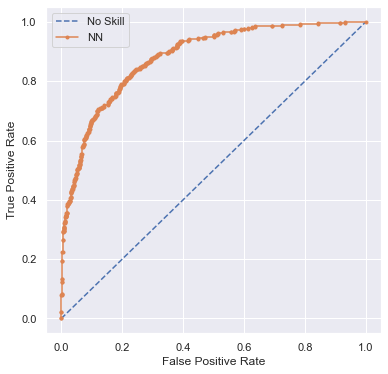

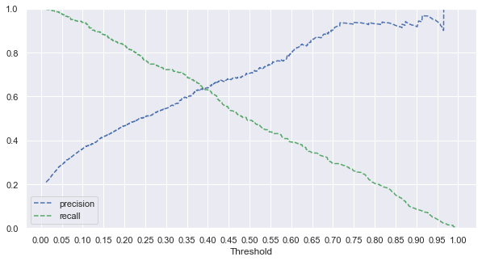

```python
#plot metrics
auc, acc, prec, rec, f1, thr, rec_thr = plot_model_metrics(model,X_val,y_val)
```

```python
scores_columns = ['Model','AUC','Accuracy','Precision','Recall','f1-score',
                 'Optimal Threshold', 'Recall at opt thr']
scores = pd.DataFrame([['13/27 Two layers NN', auc, acc, prec, rec, f1, thr, rec_thr]],
                      columns=scores_columns)
scores
```

|  | Model | AUC | Accuracy | Precision | Recall | f1-score | Optimal Threshold | Recall at opt thr |
| --- | --- | --- | --- | --- | --- | --- | --- | --- |
| 0 | 13/27 Two layers NN | 0.882 | 0.858 | 0.705 | 0.491 | 0.579 | 0.389 | 0.633 |

Model performance with the inital NN and using default threshold is low with large number of False Negatives.

```python
def plot_loss_by_epoch(history):
    # Capturing learning history per epoch
    hist  = pd.DataFrame(history.history)
    hist['epoch'] = history.epoch

    # Plotting accuracy at different epochs
    plt.plot(hist['loss'])
    plt.plot(hist['val_loss'])
    plt.legend(("train" , "valid") , loc =0)
    plt.show()
```

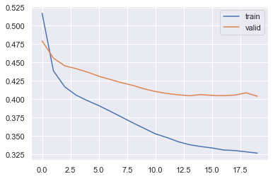

```python
plot_loss_by_epoch(history)
```

We will try different NN hyperparameter to see if we can get better performance.

As the target class is imbalanced, we will also train with undersampled and upsampled data to see if we can improve performance.

```python
# current counts of target label
print("Before UpSampling, counts of Exited = 1: {}".format(sum(y_train == 1)))
print("Before UpSampling, counts of Exited = 0: {} \n".format(sum(y_train == 0)))
```

```
Before UpSampling, counts of Exited = 1: 1186
Before UpSampling, counts of Exited = 0: 4763
```

```python
# Use SMOTE to oversample
sm_oversampler = SMOTE(sampling_strategy=1, k_neighbors=5, random_state=1)
X_train_oversmpl, y_train_oversmpl = sm_oversampler.fit_resample(X_train, y_train)

# post oversample counts of target label
print("After UpSampling, counts of Exited = 1: {}".format(sum(y_train_oversmpl == 1)))
print("After UpSampling, counts of Exited = 0: {} \n".format(sum(y_train_oversmpl == 0)))
print(f"Shape of oversample dataframes: X: {X_train_oversmpl.shape}, y: {y_train_oversmpl.shape}")
```

```
After UpSampling, counts of Exited = 1: 4763
After UpSampling, counts of Exited = 0: 4763

Shape of oversample dataframes: X: (9526, 11), y: (9526,)
```

```
Model name: XGBoost
===========
> Avg. Score:(train) 0.87508 CV scores: [0.88037775 0.8697479  0.875      0.86358867 0.88667366]
> Validation recall: 0.53671

Confusion matrix: train set

Accuracy=0.963 - Precision=0.986 - Recall=0.940 - F1 Score=0.962
```

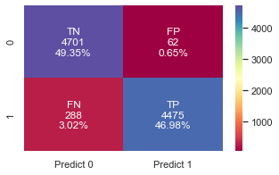

```
Confusion matrix: validation set

Accuracy=0.861 - Precision=0.697 - Recall=0.537 - F1 Score=0.607
```

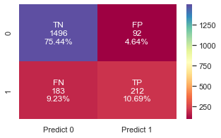

```
No Skill: ROC AUC=0.500
Model: ROC AUC=0.857
```

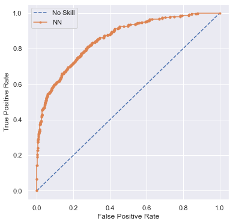

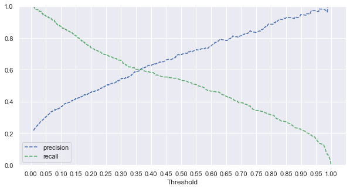

```python
run_ml_models(X_train_oversmpl,y_train_oversmpl,X_val,y_val)
```

Use oversampled data to train NN.

```python
model = create_model(model_layers_13_27)
history = model.fit(X_train_oversmpl, y_train_oversmpl, epochs=10,validation_split=0.2)
```

```
Accuracy=0.825 - Precision=0.546 - Recall=0.711 - F1 Score=0.618
```

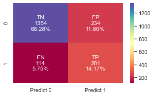

```
No Skill: ROC AUC=0.500
Model: ROC AUC=0.881
```

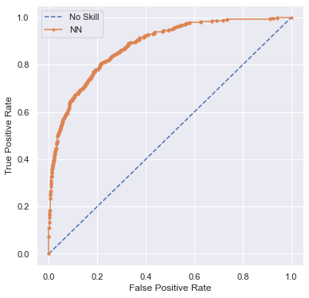

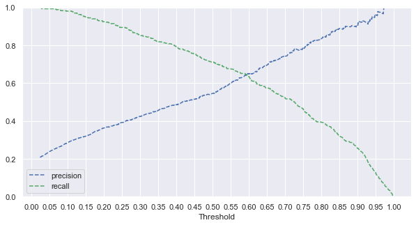

|  | Model | AUC | Accuracy | Precision | Recall | f1-score | Optimal Threshold | Recall at opt thr |
| --- | --- | --- | --- | --- | --- | --- | --- | --- |
| 0 | 13/27 Two layers NN | 0.882 | 0.858 | 0.705 | 0.491 | 0.579 | 0.389 | 0.633 |
| 1 | NN 13/27 Oversampled X | 0.881 | 0.825 | 0.546 | 0.711 | 0.618 | 0.594 | 0.641 |

```python
# plot metrics
auc, acc, prec, rec, f1, thr, rec_thr = plot_model_metrics(model, X_val, y_val)
scores.loc[len(scores.index)] = ['NN 13/27 Oversampled X', auc, acc, prec, rec, f1, thr, rec_thr]
scores
```

NN trained with oversampled data has higher recall.

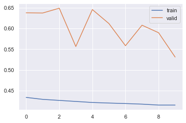

```python
plot_loss_by_epoch(history)
```

Train models using undersampled data.

```python
# current counts of target label
print("Before undersampling, counts of Exited = 1: {}".format(sum(y_train == 1)))
print("Before undersampling, counts of Exited = 0: {} \n".format(sum(y_train == 0)))
```

```
Before undersampling, counts of Exited = 1: 1186
Before undersampling, counts of Exited = 0: 4763
```

```python
# get instance of undersampler
undersampler = RandomUnderSampler(sampling_strategy='majority', random_state=1, replacement=False)

# resample the data
X_train_undersmpl, y_train_undersmpl = undersampler.fit_resample(X_train, y_train)

# post oversample counts of target label
print("After undersampling, counts of Exited = 1: {}".format(sum(y_train_undersmpl == 1)))
print("After undersampling, counts of Exited = 0: {} \n".format(sum(y_train_undersmpl == 0)))
print(f"Shape of oversample dataframes: X: {X_train_undersmpl.shape}, y: {y_train_undersmpl.shape}")
```

```
After undersampling, counts of Exited = 1: 1186
After undersampling, counts of Exited = 0: 1186

Shape of oversample dataframes: X: (2372, 11), y: (2372,)
```

```
Model name: XGBoost
===========
> Avg. Score:(train) 0.72006 CV scores: [0.74683544 0.72689076 0.66244726 0.72151899 0.74261603]
> Validation recall: 0.73418

Confusion matrix: train set

Accuracy=0.994 - Precision=0.994 - Recall=0.994 - F1 Score=0.994
```

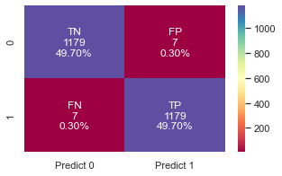

```
Confusion matrix: validation set

Accuracy=0.753 - Precision=0.430 - Recall=0.734 - F1 Score=0.542
```

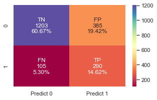

```
No Skill: ROC AUC=0.500
Model: ROC AUC=0.832
```

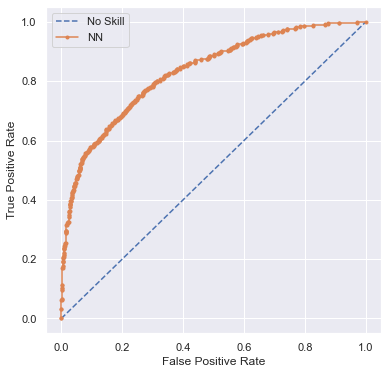

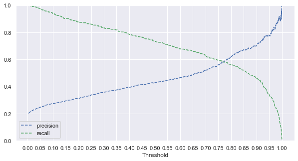

```python
run_ml_models(X_train_undersmpl, y_train_undersmpl, X_val, y_val)
```

Recall of XGBoost is at 0.733 against validation set but the model is overfit (train recall 0.994 vs validation at 0.733)

Train NN with undersampled data.

```python
model = create_model(model_layers_13_27)
history = model.fit(X_train_undersmpl, y_train_undersmpl, epochs=10,validation_split=0.2)
```

```
Accuracy=0.839 - Precision=0.579 - Recall=0.696 - F1 Score=0.632
```

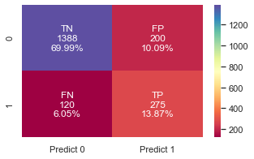

```
No Skill: ROC AUC=0.500
Model: ROC AUC=0.875
```

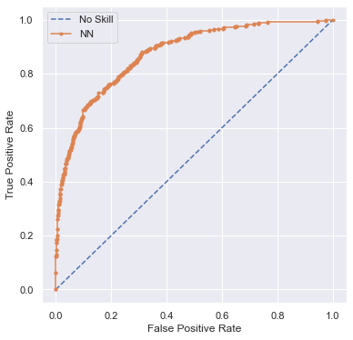

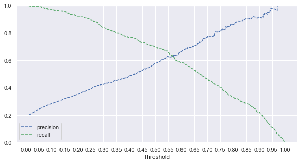

|  | Model | AUC | Accuracy | Precision | Recall | f1-score | Optimal Threshold | Recall at opt thr |
| --- | --- | --- | --- | --- | --- | --- | --- | --- |
| 0 | 13/27 Two layers NN | 0.882 | 0.858 | 0.705 | 0.491 | 0.579 | 0.389 | 0.633 |
| 1 | NN 13/27 Oversampled X | 0.881 | 0.825 | 0.546 | 0.711 | 0.618 | 0.594 | 0.641 |
| 2 | NN 13/27 Undersampled X | 0.875 | 0.839 | 0.579 | 0.696 | 0.632 | 0.568 | 0.625 |

```python
auc, acc, prec, rec, f1, thr, rec_thr = plot_model_metrics(model, X_val, y_val)
scores.loc[len(scores.index)] = ['NN 13/27 Undersampled X', auc, acc, prec, rec, f1, thr, rec_thr]
scores
```

Recall is slightly lower compared to model fit on oversampled but still higher than initial model.

However, AUC score is very similar for all NN models so far. By varying the threshold, similar scores can be achieved.

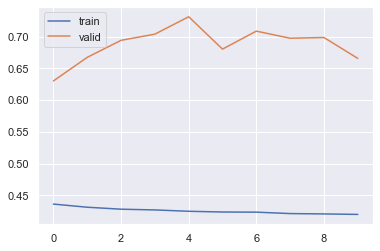

```python
plot_loss_by_epoch(history)
```

Try with higher number of epochs against initial model (13/27 hidden layers and train on X_train)

```python
create_model(model_layers_13_27)
history = model.fit(X_train, y_train, epochs=20,validation_split=0.2)
```

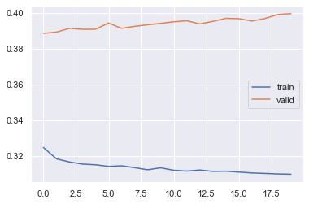

```python
plot_loss_by_epoch(history)
```

```
Accuracy=0.867 - Precision=0.808 - Recall=0.438 - F1 Score=0.568
```

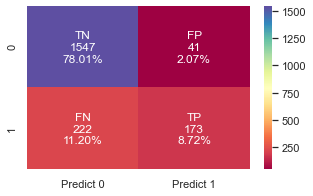

```
No Skill: ROC AUC=0.500
Model: ROC AUC=0.875
```

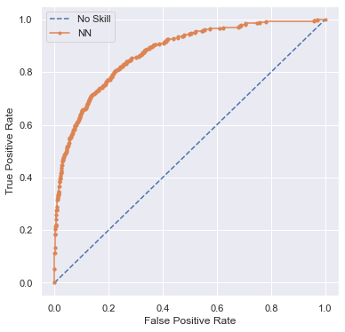

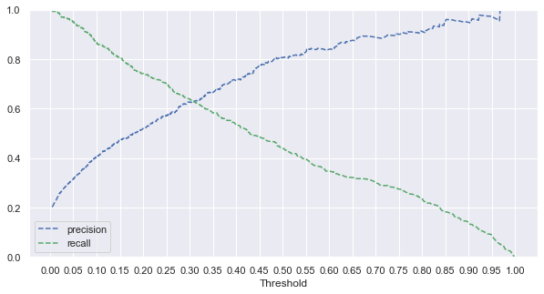

|  | Model | AUC | Accuracy | Precision | Recall | f1-score | Optimal Threshold | Recall at opt thr |
| --- | --- | --- | --- | --- | --- | --- | --- | --- |
| 0 | 13/27 Two layers NN | 0.882 | 0.858 | 0.705 | 0.491 | 0.579 | 0.389 | 0.633 |
| 1 | NN 13/27 Oversampled X | 0.881 | 0.825 | 0.546 | 0.711 | 0.618 | 0.594 | 0.641 |
| 2 | NN 13/27 Undersampled X | 0.875 | 0.839 | 0.579 | 0.696 | 0.632 | 0.568 | 0.625 |
| 3 | NN 13/27 X_Train - 20 Epochs | 0.875 | 0.867 | 0.808 | 0.438 | 0.568 | 0.307 | 0.628 |

```python
auc, acc, prec, rec, f1, thr, rec_thr = plot_model_metrics(model, X_val, y_val)
scores.loc[len(scores.index)] = ['NN 13/27 X_Train - 20 Epochs', auc, acc, prec, rec, f1, thr, rec_thr]
scores
```

Try to change the number of neurons in hidden layers.

```python
model_layers_27_100 = [
    Dense(units=27, input_shape=(X_train.shape[1],) , activation='relu'),
    Dense(100, activation='relu'),
    Dense(1, activation=tf.keras.activations.sigmoid)
]

create_model(model_layers_27_100)
history = model.fit(X_train, y_train, epochs=20,validation_split=0.2, verbose=0)
```

```
Accuracy=0.866 - Precision=0.755 - Recall=0.484 - F1 Score=0.590
```

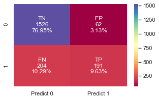

```
No Skill: ROC AUC=0.500
Model: ROC AUC=0.875
```

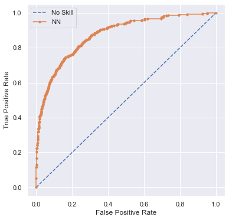

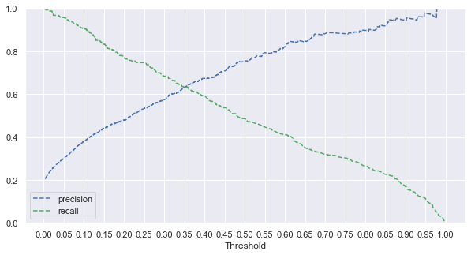

|  | Model | AUC | Accuracy | Precision | Recall | f1-score | Optimal Threshold | Recall at opt thr |
| --- | --- | --- | --- | --- | --- | --- | --- | --- |
| 0 | 13/27 Two layers NN | 0.882 | 0.858 | 0.705 | 0.491 | 0.579 | 0.389 | 0.633 |
| 1 | NN 13/27 Oversampled X | 0.881 | 0.825 | 0.546 | 0.711 | 0.618 | 0.594 | 0.641 |
| 2 | NN 13/27 Undersampled X | 0.875 | 0.839 | 0.579 | 0.696 | 0.632 | 0.568 | 0.625 |
| 3 | NN 13/27 X_Train - 20 Epochs | 0.875 | 0.867 | 0.808 | 0.438 | 0.568 | 0.307 | 0.628 |
| 4 | NN 27/100 - 20 Epochs | 0.875 | 0.866 | 0.755 | 0.484 | 0.590 | 0.352 | 0.633 |

```python
auc, acc, prec, rec, f1, thr, rec_thr = plot_model_metrics(model, X_val, y_val)
scores.loc[len(scores.index)] = ['NN 27/100 - 20 Epochs', auc, acc, prec, rec, f1, thr, rec_thr]
scores
```

No gains compared to the previous networks.

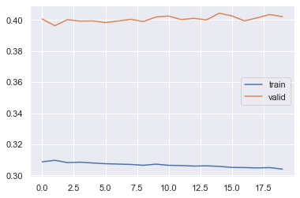

```python
plot_loss_by_epoch(history)
```

As the target class is imbalanced, we will test using class_weight to compensate for the imbalance.

```python
from sklearn.utils import class_weight
class_weights = class_weight.compute_class_weight(class_weight='balanced',
                                                  classes=np.unique(y_train),
                                                  y=np.array([y_train.iloc[i] for i in range(len(y_train))]))
class_weights = dict(enumerate(class_weights))
class_weights
```

```
{0: 0.6245013646861222, 1: 2.508010118043845}
```

```python
create_model(model_layers_27_100)
history = model.fit(X_train,y_train,batch_size=15,epochs=10, class_weight=class_weights, validation_split=0.2,shuffle=True)
```

```
Accuracy=0.773 - Precision=0.459 - Recall=0.782 - F1 Score=0.579
```

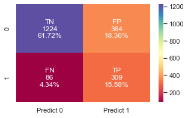

```
No Skill: ROC AUC=0.500
Model: ROC AUC=0.870
```

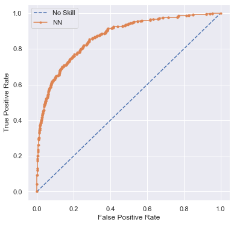

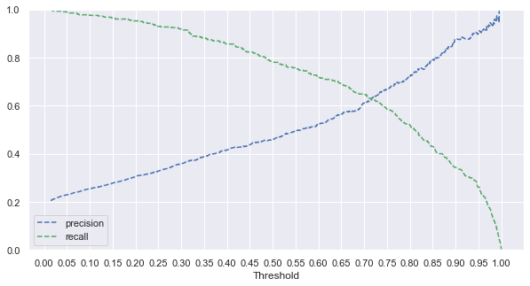

|  | Model | AUC | Accuracy | Precision | Recall | f1-score | Optimal Threshold | Recall at opt thr |
| --- | --- | --- | --- | --- | --- | --- | --- | --- |
| 0 | 13/27 Two layers NN | 0.882 | 0.858 | 0.705 | 0.491 | 0.579 | 0.389 | 0.633 |
| 1 | NN 13/27 Oversampled X | 0.881 | 0.825 | 0.546 | 0.711 | 0.618 | 0.594 | 0.641 |
| 2 | NN 13/27 Undersampled X | 0.875 | 0.839 | 0.579 | 0.696 | 0.632 | 0.568 | 0.625 |
| 3 | NN 13/27 X_Train - 20 Epochs | 0.875 | 0.867 | 0.808 | 0.438 | 0.568 | 0.307 | 0.628 |
| 4 | NN 27/100 - 20 Epochs | 0.875 | 0.866 | 0.755 | 0.484 | 0.590 | 0.352 | 0.633 |
| 5 | NN 27/100 - 10 Ep + class_weights | 0.870 | 0.773 | 0.459 | 0.782 | 0.579 | 0.716 | 0.628 |

```python
auc, acc, prec, rec, f1, thr, rec_thr = plot_model_metrics(model, X_val, y_val)
scores.loc[len(scores.index)] = ['NN 27/100 - 10 Ep + class_weights', auc, acc, prec, rec, f1, thr, rec_thr]
scores
```

AUC is not improved compared to previous models. Recall with default threshold is higher but again at the cost of precision.

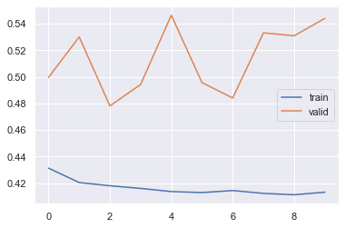

```python
plot_loss_by_epoch(history)
```

Trying with Dropout layers and different kernel initializer.

```python
# Tune weight initialization and add drop layers
from tensorflow.keras.layers import Dropout

# early stopping callback
es= tf.keras.callbacks.EarlyStopping(monitor='val_loss',
                              min_delta=0,
                              patience=15,
                             verbose=0, mode='min', restore_best_weights= True)
model2 = Sequential()
# Initialize the weights using hue_normal
model2.add(Dense(65, input_shape=(X_train.shape[1], ), kernel_initializer='he_normal', activation='relu'))
model2.add(Dropout(0.5))
model2.add(Dense(65, kernel_initializer='he_normal', activation='relu'))
model2.add(Dropout(0.5))
model2.add(Dense(1, kernel_initializer='he_normal', activation='sigmoid'))

recall_metric = tf.keras.metrics.Recall()

model2.compile(optimizer=tf.optimizers.Adam(learning_rate=0.001),
               loss='binary_crossentropy',
               metrics=[recall_metric])

his_mod2 = model2.fit(X_train, y_train,
                     validation_split=0.2,
                     batch_size=700,
                     epochs=20,
                     callbacks=[es],
                     shuffle=True,
                     class_weight=class_weights)
```

```
Accuracy=0.699 - Precision=0.374 - Recall=0.757 - F1 Score=0.501
```

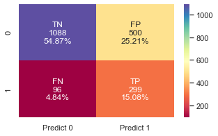

```
No Skill: ROC AUC=0.500
Model: ROC AUC=0.800
```

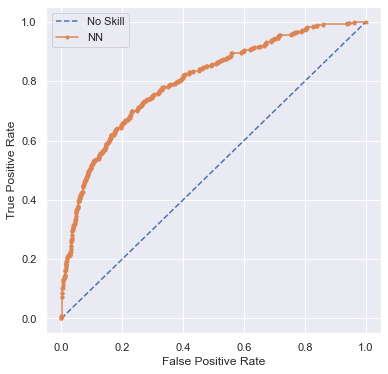

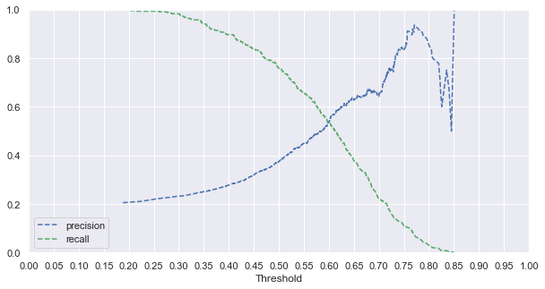

|  | Model | AUC | Accuracy | Precision | Recall | f1-score | Optimal Threshold | Recall at opt thr |
| --- | --- | --- | --- | --- | --- | --- | --- | --- |
| 0 | 13/27 Two layers NN | 0.882 | 0.858 | 0.705 | 0.491 | 0.579 | 0.389 | 0.633 |
| 1 | NN 13/27 Oversampled X | 0.881 | 0.825 | 0.546 | 0.711 | 0.618 | 0.594 | 0.641 |
| 2 | NN 13/27 Undersampled X | 0.875 | 0.839 | 0.579 | 0.696 | 0.632 | 0.568 | 0.625 |
| 3 | NN 13/27 X_Train - 20 Epochs | 0.875 | 0.867 | 0.808 | 0.438 | 0.568 | 0.307 | 0.628 |
| 4 | NN 27/100 - 20 Epochs | 0.875 | 0.866 | 0.755 | 0.484 | 0.590 | 0.352 | 0.633 |
| 5 | NN 27/100 - 10 Ep + class_weights | 0.870 | 0.773 | 0.459 | 0.782 | 0.579 | 0.716 | 0.628 |
| 6 | NN 65/drop/65/drop - 20 Ep + class weights | 0.800 | 0.699 | 0.374 | 0.757 | 0.501 | 0.600 | 0.537 |

```python
#plot metrics
auc, acc, prec, rec, f1, thr, rec_thr = plot_model_metrics(model2, X_val, y_val)
scores.loc[len(scores.index)] = ['NN 65/drop/65/drop - 20 Ep + class weights',
                                 auc, acc, prec, rec, f1, thr, rec_thr]
scores
```

AUC is lower than all previous models.

The recall with default threshold is > 0.7 but it corresponds to the lowest precision across all models.

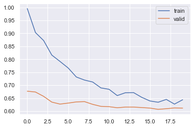

```python
plot_loss_by_epoch(his_mod2)
```

#### Pick Best model and evaluate performance against test data set

Most models have accuracy > 80%

We will use '13/27 Two layers NN' as the preferred model.

##### Performance against test set

Get new instance of the model and train on X_train.

```python
# get model instance
best_model = create_model(model_layers_13_27)

# train best model on X_train
best_history = best_model.fit(X_train, y_train, epochs=20,validation_split=0.2)
```

Plot metrics against validation set to verify that model has similar performance to the selected one.

```
Accuracy=0.862 - Precision=0.738 - Recall=0.478 - F1 Score=0.581
```

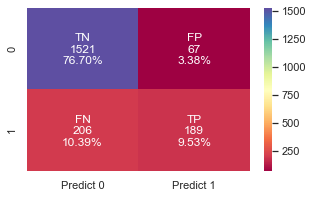

```
No Skill: ROC AUC=0.500
Model: ROC AUC=0.866
```

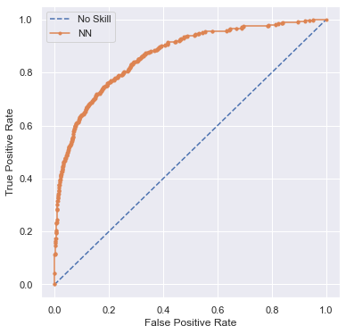

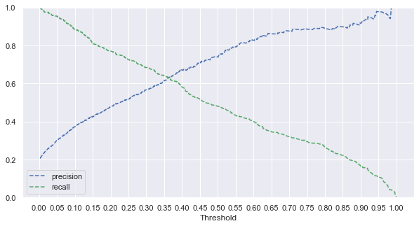

|  | Model | AUC | Accuracy | Precision | Recall | f1-score | Optimal Threshold | Recall at opt thr |
| --- | --- | --- | --- | --- | --- | --- | --- | --- |
| 0 | 13/27 Two layers NN | 0.882 | 0.858 | 0.705 | 0.491 | 0.579 | 0.389 | 0.633 |
| 1 | NN 13/27 Oversampled X | 0.881 | 0.825 | 0.546 | 0.711 | 0.618 | 0.594 | 0.641 |
| 2 | NN 13/27 Undersampled X | 0.875 | 0.839 | 0.579 | 0.696 | 0.632 | 0.568 | 0.625 |
| 3 | NN 13/27 X_Train - 20 Epochs | 0.875 | 0.867 | 0.808 | 0.438 | 0.568 | 0.307 | 0.628 |
| 4 | NN 27/100 - 20 Epochs | 0.875 | 0.866 | 0.755 | 0.484 | 0.590 | 0.352 | 0.633 |
| 5 | NN 27/100 - 10 Ep + class_weights | 0.870 | 0.773 | 0.459 | 0.782 | 0.579 | 0.716 | 0.628 |
| 6 | NN 65/drop/65/drop - 20 Ep + class weights | 0.800 | 0.699 | 0.374 | 0.757 | 0.501 | 0.600 | 0.537 |
| 7 | Best model 13/27 Two layers NN - VALIDATION set | 0.866 | 0.862 | 0.738 | 0.478 | 0.581 | 0.362 | 0.630 |

```python
# Sanity check against validation data
auc, acc, prec, rec, f1, thr, rec_thr = plot_model_metrics(best_model, X_val, y_val)
scores.loc[len(scores.index)] = ['Best model 13/27 Two layers NN - VALIDATION set',
                                 auc, acc, prec, rec, f1, thr, rec_thr]
scores
```

Get performance on TEST set.

```
Accuracy=0.851 - Precision=0.689 - Recall=0.461 - F1 Score=0.552
```

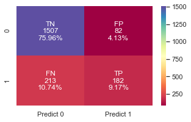

```
No Skill: ROC AUC=0.500
Model: ROC AUC=0.827
```

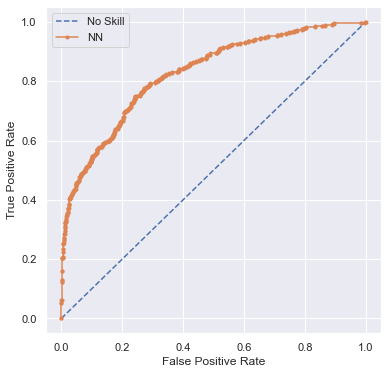

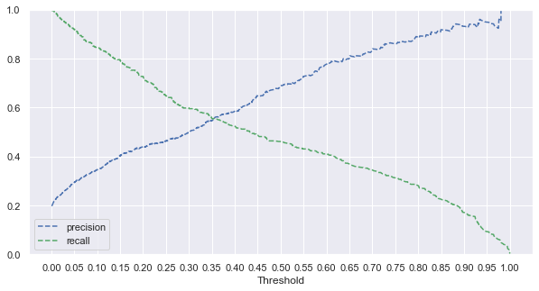

|  | Model | AUC | Accuracy | Precision | Recall | f1-score | Optimal Threshold | Recall at opt thr |
| --- | --- | --- | --- | --- | --- | --- | --- | --- |
| 0 | 13/27 Two layers NN | 0.882 | 0.858 | 0.705 | 0.491 | 0.579 | 0.389 | 0.633 |
| 1 | NN 13/27 Oversampled X | 0.881 | 0.825 | 0.546 | 0.711 | 0.618 | 0.594 | 0.641 |
| 2 | NN 13/27 Undersampled X | 0.875 | 0.839 | 0.579 | 0.696 | 0.632 | 0.568 | 0.625 |
| 3 | NN 13/27 X_Train - 20 Epochs | 0.875 | 0.867 | 0.808 | 0.438 | 0.568 | 0.307 | 0.628 |
| 4 | NN 27/100 - 20 Epochs | 0.875 | 0.866 | 0.755 | 0.484 | 0.590 | 0.352 | 0.633 |
| 5 | NN 27/100 - 10 Ep + class_weights | 0.870 | 0.773 | 0.459 | 0.782 | 0.579 | 0.716 | 0.628 |
| 6 | NN 65/drop/65/drop - 20 Ep + class weights | 0.800 | 0.699 | 0.374 | 0.757 | 0.501 | 0.600 | 0.537 |
| 7 | Best model 13/27 Two layers NN - VALIDATION set | 0.866 | 0.862 | 0.738 | 0.478 | 0.581 | 0.362 | 0.630 |
| 8 | Best model 13/27 Two layers NN - TEST set | 0.827 | 0.851 | 0.689 | 0.461 | 0.552 | 0.355 | 0.554 |

```python
# Performance on TEST set
auc, acc, prec, rec, f1, thr, rec_thr = plot_model_metrics(best_model, X_test, y_test)
scores.loc[len(scores.index)] = ['Best model 13/27 Two layers NN - TEST set',
                                 auc, acc, prec, rec, f1, thr, rec_thr]
scores
```

Plot confusion matrix using the optimal threshold (precision=recall) on test

```
Best Threshold: 0.3550916314125061

Accuracy=0.823 - Precision=0.556 - Recall=0.554 - F1 Score=0.555
```

```
(0.8230846774193549,
 0.5558375634517766,
 0.5544303797468354,
 0.5551330798479087)
```

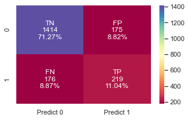

```python
# confusion matrix on TEST set using best threshold
best_threshold = scores.loc[8]['Optimal Threshold']
print('Best Threshold:', best_threshold)
plot_confusion_matrix(best_model, X_test, y_test, threshold=best_threshold)
```

### Best Model Performance

The performance on test set is:

- AUC > 0.8,
- recall with optimal threshold (precision=recall) > 0.5,
- accuracy > 0.8

The model chosen is slightly overfit.

#### Possible improvements

- Better ways of preprocessing the data
  - Use a better scaler than standard scaler. StandardScaler() is sensitive to outliers and doesn't preserve the original distribution if it is not gaussian.
  - `Balance` could be broken down in 3 or 4 levels to see if it results in better performance
  - Rather than dropping outliers, instead cap or impute mean/median which might yield better results.  
    Alternatively, drop outliers only in the train set rather than prior to splitting the data.
  - `CreditScore` has a peak at the max of the range and outliers at bottom of the range.  
    It might benefit from being broken down into levels (e.g. low, medium, high)
  - `Estimated Salary` has uniform distribution which doesn't seem realistic. Removing this column might improve the model.
- Hyperparameters tuning
  - test with differrent weights initializations, and loss functions
  - test with different learning rates and epochs
  - test with different optimizers (e.g. SGD)
  - use random or grid search to tune the models
- Threshold
  - predictions could be made with lower thresholds to reduce the number of false negatives (higher recall), at the cost of more false positives (lower precision)

## Conclusions

### Models

We were able to train multiple neural network models against the data to predict whether a customer will leave the bank or not.

Models performance varied but most have an AUC score greater than 0.8 on validation set.

The model picked as best has AUC > 0.8 on the test set.

Using optimal threshold (Precision=Recall) for classification achieves a recall > 0.5. Higher recall can be achieved with lower threshold at the expense of precision.

### Business recommendations

The neural network models make it difficult to interpret the weights to identify feature importance.

Based on the EDA:

- The higher the age, the more likely that the customer will leave. Efforts should be made to identify customer segments and have targeted age-aware campaigns to retain more customers.
- Customers with zero balance are less likely to leave the bank. Here too, efforts should be made to identify customers segments that have non-zero balance and target for retention.
- Customers from Germany are more likely to leave the bank. A market analysis should be conducted to compare the bank's offerings in Germany against competitors and aim to reduce the offerings gap and promote superior offerings.
- Females are more likely to leave the bank. Customer segmentation should be performed to identify what other factors influence this rate and target customers with gender-aware campaigns.
- Inactive customers leave at higher rates than active. Customers who have a downward trend on their activities or are inactive should be targeted for retention.
- Customers who use less products are more likely to leave. Customers using only 1 product should be targeted in a campaign to raise awareness of the banks offerings and incentivize the use of more products.